# Specialty Pharmacy Curriculum Survey

Authors

Ryan Moore

Department of Biostatistics

Vanderbilt University Medical Center

Published

June 5, 2025

# 1 Study Overview

## 1.1 Background

The purpose of this study is to fill a gap in literature by evaluating the scope and depth of didactic and experiential instruction on specialty pharmacy in schools and colleges of pharmacy in the United States.

## 1.2 Methods

- Sample is faculty members from 140 schools of pharmacy and 328 contacts in the US
- Sampling included a primary contact who was identified to be the faculty member closest to the Academic Affairs division, then additional contacts added as more reminders were sent.
- Survey closed Sunday, 11/3/24

## 1.3 Outcomes

Descriptive results

# 2 Descriptive Statistics

## 2.1 Participation

**Table**

| Participation | Participation N | Participation *N=140* |
| --- | --- | --- |
| survey_complete | 140 |  |
| Complete |  | 29% (41) |
| Incomplete |  | 71% (99) |

*N* is the number of non-missing values. Numbers after proportions are frequencies.

**Figure**

[figure not shown]

## 2.2 Survey

| **Characteristic** | **N** | **N = 41**<sup>1</sup> |
| --- | --- | --- |
| Is this college/school public or private? | 41 |  |
| Private |  | 20 (48.8%) |
| Public |  | 21 (51.2%) |
| Primary college/school setting | 41 |  |
| Rural |  | 8 (19.5%) |
| Suburban |  | 15 (36.6%) |
| Urban |  | 18 (43.9%) |
| State | 41 |  |
| Alabama |  | 2 (4.88%) |
| Arkansas |  | 1 (2.44%) |
| California |  | 2 (4.88%) |
| Florida |  | 3 (7.32%) |
| Georgia |  | 2 (4.88%) |
| Illinois |  | 2 (4.88%) |
| Iowa |  | 1 (2.44%) |
| Kansas |  | 1 (2.44%) |
| Louisiana |  | 3 (7.32%) |
| Maine |  | 1 (2.44%) |
| Maryland |  | 1 (2.44%) |
| Michigan |  | 1 (2.44%) |
| Missouri |  | 1 (2.44%) |
| Nebraska |  | 1 (2.44%) |
| New Hampshire |  | 1 (2.44%) |
| New York |  | 1 (2.44%) |
| North Carolina |  | 1 (2.44%) |
| Ohio |  | 1 (2.44%) |
| Oklahoma |  | 2 (4.88%) |
| Pennsylvania |  | 1 (2.44%) |
| Rhode Island |  | 1 (2.44%) |
| South Carolina |  | 1 (2.44%) |
| South Dakota |  | 1 (2.44%) |
| Tennessee |  | 3 (7.32%) |
| Virginia |  | 1 (2.44%) |
| Washington D.C. |  | 1 (2.44%) |
| West Virginia |  | 1 (2.44%) |
| Wisconsin |  | 2 (4.88%) |
| Wyoming |  | 1 (2.44%) |
| Geographic region | 41 |  |
| Midwest |  | 11 (26.8%) |
| Northeast |  | 6 (14.6%) |
| Southeast |  | 19 (46.3%) |
| Southwest |  | 2 (4.88%) |
| West |  | 3 (7.32%) |
| What is the estimated enrollment size of students entering the (P1) PharmD class for 2024/2025? | 41 |  |
| < 26 |  | 3 (7.32%) |
| 26-50 |  | 13 (31.7%) |
| 51-75 |  | 16 (39.0%) |
| 76-100 |  | 4 (9.76%) |
| >100 |  | 5 (12.2%) |
| Do you have a faculty member (full or affiliate) practicing in a specialty pharmacy owned and operated by a health system? | 41 |  |
| No |  | 27 (65.9%) |
| Unsure |  | 3 (7.32%) |
| Yes |  | 11 (26.8%) |
| Do you offer any specialty pharmacy focused didactic elective courses? | 41 |  |
| No |  | 33 (80.5%) |
| Unsure |  | 1 (2.44%) |
| Yes |  | 7 (17.1%) |

<sup>1</sup> n (%)

## 2.3 Sections

### 2.3.1 Didactic Course Information

**SP Faculty**

| **Characteristic** | **N** | **sp** **No SP Faculty**, N = 30<sup>1</sup> | **sp** **SP Faculty**, N = 11<sup>1</sup> |
| --- | --- | --- | --- |
| Do you offer any specialty pharmacy focused didactic elective courses? | 41 |  |  |
| No |  | 28 (93.3%) | 5 (45.5%) |
| Unsure |  | 0 (0%) | 1 (9.09%) |
| Yes |  | 2 (6.67%) | 5 (45.5%) |
| Please provide the estimated number of credit hours that specialty pharmacy elective(s) are offered. | 7 |  |  |
| 2 |  | 2 (100.0%) | 4 (80.0%) |
| 4 |  | 0 (0%) | 1 (20.0%) |
| Missing |  | 28 | 6 |
| Please provide the approximate number of students that complete a specialty pharmacy elective annually. | 7 |  |  |
| 3 |  | 1 (50.0%) | 0 (0%) |
| 5 |  | 0 (0%) | 1 (20.0%) |
| 8 |  | 1 (50.0%) | 1 (20.0%) |
| 10 |  | 0 (0%) | 1 (20.0%) |
| 20 |  | 0 (0%) | 1 (20.0%) |
| 40 |  | 0 (0%) | 1 (20.0%) |
| Missing |  | 28 | 6 |

<sup>1</sup> n (%)

**Granular**

| **Characteristic** | **N** | **N = 41**<sup>1</sup> |
| --- | --- | --- |
| Do you offer any specialty pharmacy focused didactic elective courses? | 41 |  |
| No |  | 33 (80.5%) |
| Unsure |  | 1 (2.44%) |
| Yes |  | 7 (17.1%) |
| Please provide the estimated number of credit hours that specialty pharmacy elective(s) are offered. | 7 |  |
| 2 |  | 6 (85.7%) |
| 4 |  | 1 (14.3%) |
| Missing |  | 34 |
| Please provide the approximate number of students that complete a specialty pharmacy elective annually. | 7 |  |
| 3 |  | 1 (14.3%) |
| 5 |  | 1 (14.3%) |
| 8 |  | 2 (28.6%) |
| 10 |  | 1 (14.3%) |
| 20 |  | 1 (14.3%) |
| 40 |  | 1 (14.3%) |
| Missing |  | 34 |

<sup>1</sup> n (%)

**Continous**

| **Characteristic** | **N** | **N = 41**<sup>1</sup> |
| --- | --- | --- |
| Do you offer any specialty pharmacy focused didactic elective courses? | 41 |  |
| No |  | 33 (80.5%) |
| Unsure |  | 1 (2.44%) |
| Yes |  | 7 (17.1%) |
| Please provide the estimated number of credit hours that specialty pharmacy elective(s) are offered. | 7 |  |
| Mean (SD) |  | 2.3 (0.8) |
| Median (IQR) |  | 2.0 (2.0 - 2.0) |
| Range |  | 2.0 - 4.0 |
| Missing |  | 34 |
| Please provide the approximate number of students that complete a specialty pharmacy elective annually. | 7 |  |
| Mean (SD) |  | 13.4 (12.9) |
| Median (IQR) |  | 8.0 (6.5 - 15.0) |
| Range |  | 3.0 - 40.0 |
| Missing |  | 34 |

<sup>1</sup> n (%)

#### 2.3.1.1 Topics covered in elective courses

**Figure**

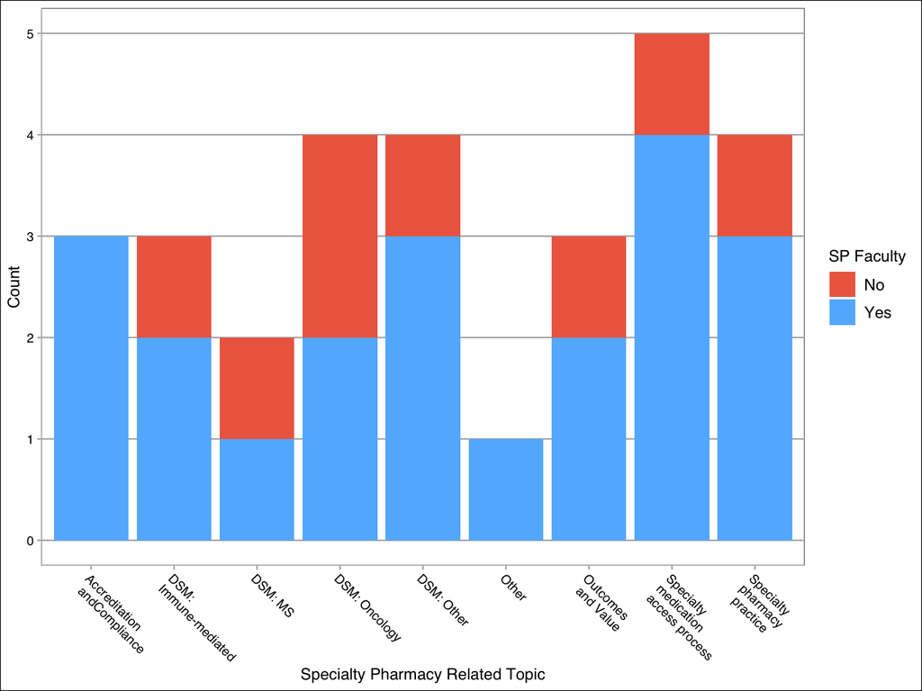

**By participant**

| **Characteristic** | **N = 7**<sup>1</sup> |
| --- | --- |
| Specialty medication access process (benefit investigation, prior authorization, appeal of insurance determination, and financial assistance) | 5 (71.4%) |
| Specialty pharmacy practice (SP business, stakeholders, models, role of PharmD) | 4 (57.1%) |
| Disease state management: Oncology | 4 (57.1%) |
| Disease state management: Other specialty conditions | 4 (57.1%) |
| Accreditation/Compliance | 3 (42.9%) |
| Outcomes/Value | 3 (42.9%) |
| Disease state management: Immune-mediated | 3 (42.9%) |
| Disease state management: Multiple Sclerosis | 2 (28.6%) |
| Other | 1 (14.3%) |

<sup>1</sup> n (%)

**By response**

| **Characteristic** | **N** | **N = 29**<sup>1</sup> |
| --- | --- | --- |
| Selection | 29 |  |
| Specialty medication access process (benefit investigation, prior authorization, appeal of insurance determination, and financial assistance) |  | 5 (17.2%) |
| Disease state management: Oncology |  | 4 (13.8%) |
| Disease state management: Other specialty conditions |  | 4 (13.8%) |
| Specialty pharmacy practice (SP business, stakeholders, models, role of PharmD) |  | 4 (13.8%) |
| Accreditation/Compliance |  | 3 (10.3%) |
| Disease state management: Immune-mediated |  | 3 (10.3%) |
| Outcomes/Value |  | 3 (10.3%) |
| Disease state management: Multiple Sclerosis |  | 2 (6.90%) |
| Other |  | 1 (3.45%) |

<sup>1</sup> n (%)

**Free text**

Other SP Content

| x |
| --- |
| pipeline surveillance, forecasting, and contracting; clinical auditing; proactive adherence monitoring and technician's role; recruiting, talent development, and careers in specialty pharmacy |

#### 2.3.1.2 Years elective course offered

| **Characteristic** | **N = 7**<sup>1</sup> |
| --- | --- |
| P3 year |  |
| Yes | 7 (100.0%) |
| P2 year | 5 (71.4%) |
| P1 year | 1 (14.3%) |

<sup>1</sup> n (%)

### 2.3.2 How are the following specialty pharmacy (SP) topics covered in your DIDACTIC curriculum?

#### 2.3.2.1 Specialty pharmacy practice (SP business, stakeholders, accreditation, models, role of PharmD)

**Table**

**All Responses**

| **Characteristic** | **N = 41**<sup>1</sup> |
| --- | --- |
| Integrated into required course(s) | 17 (41.5%) |
| None | 13 (31.7%) |
| Integrated into elective course(s) | 8 (19.5%) |
| Unsure | 5 (12.2%) |
| Other (e.g., labs, simulations) | 4 (9.76%) |

<sup>1</sup> n (%)

**YES-Specialty pharmacy-affiliated faculty**

| **Characteristic** | **N = 11**<sup>1</sup> |
| --- | --- |
| Integrated into required course(s) | 4 (36.4%) |
| Integrated into elective course(s) | 3 (27.3%) |
| None | 2 (18.2%) |
| Unsure | 2 (18.2%) |
| Other (e.g., labs, simulations) |  |
| No | 11 (100.0%) |

<sup>1</sup> n (%)

**NO-Specialty pharmacy-affiliated faculty**

| **Characteristic** | **N = 30**<sup>1</sup> |
| --- | --- |
| Integrated into required course(s) | 13 (43.3%) |
| None | 11 (36.7%) |
| Integrated into elective course(s) | 5 (16.7%) |
| Other (e.g., labs, simulations) | 4 (13.3%) |
| Unsure | 3 (10.0%) |

<sup>1</sup> n (%)

**Free text**

Specialty pharmacy practice

| x |
| --- |
| none |
| 1 |
| None |
| none |

#### 2.3.2.2 Specialty medication access process

##### 2.3.2.2.1 Table

**All Responses**

| **Characteristic** | **N = 41**<sup>1</sup> |
| --- | --- |
| Integrated into required course(s) | 17 (41.5%) |
| Integrated into elective course(s) | 8 (19.5%) |
| Other (e.g., labs, simulations) | 8 (19.5%) |
| Unsure | 8 (19.5%) |
| None | 7 (17.1%) |

<sup>1</sup> n (%)

**YES-Specialty pharmacy-affiliated faculty**

| **Characteristic** | **N = 11**<sup>1</sup> |
| --- | --- |
| Integrated into required course(s) | 5 (45.5%) |
| Integrated into elective course(s) | 4 (36.4%) |
| Other (e.g., labs, simulations) | 1 (9.09%) |
| None | 1 (9.09%) |
| Unsure | 1 (9.09%) |

<sup>1</sup> n (%)

**NO-Specialty pharmacy-affiliated faculty**

| **Characteristic** | **N = 30**<sup>1</sup> |
| --- | --- |
| Integrated into required course(s) | 12 (40.0%) |
| Other (e.g., labs, simulations) | 7 (23.3%) |
| Unsure | 7 (23.3%) |
| None | 6 (20.0%) |
| Integrated into elective course(s) | 4 (13.3%) |

<sup>1</sup> n (%)

#### 2.3.2.3 Disease state management: Oncology

##### 2.3.2.3.1 Table

**All Responses**

| **Characteristic** | **N = 41**<sup>1</sup> |
| --- | --- |
| Integrated into required course(s) | 32 (78.0%) |
| Integrated into elective course(s) | 6 (14.6%) |
| Unsure | 5 (12.2%) |
| Other (e.g., labs, simulations) | 1 (2.44%) |
| None | 1 (2.44%) |

<sup>1</sup> n (%)

**YES-Specialty pharmacy-affiliated faculty**

| **Characteristic** | **N = 11**<sup>1</sup> |
| --- | --- |
| Integrated into required course(s) | 9 (81.8%) |
| Integrated into elective course(s) | 3 (27.3%) |
| Other (e.g., labs, simulations) | 1 (9.09%) |
| None |  |
| No | 11 (100.0%) |
| Unsure |  |
| No | 11 (100.0%) |

<sup>1</sup> n (%)

**NO-Specialty pharmacy-affiliated faculty**

| **Characteristic** | **N = 30**<sup>1</sup> |
| --- | --- |
| Integrated into required course(s) | 23 (76.7%) |
| Unsure | 5 (16.7%) |
| Integrated into elective course(s) | 3 (10.0%) |
| None | 1 (3.33%) |
| Other (e.g., labs, simulations) |  |
| No | 30 (100.0%) |

<sup>1</sup> n (%)

#### 2.3.2.4 Disease state management: Immune-mediated (RA, psoriasis, IBD)

**Table**

**All Responses**

| **Characteristic** | **N = 41**<sup>1</sup> |
| --- | --- |
| Integrated into required course(s) | 34 (82.9%) |
| Unsure | 4 (9.76%) |
| Integrated into elective course(s) | 2 (4.88%) |
| Other (e.g., labs, simulations) | 2 (4.88%) |
| None | 2 (4.88%) |

<sup>1</sup> n (%)

**YES-Specialty pharmacy-affiliated faculty**

| **Characteristic** | **N = 11**<sup>1</sup> |
| --- | --- |
| Integrated into required course(s) | 10 (90.9%) |
| Integrated into elective course(s) | 2 (18.2%) |
| Other (e.g., labs, simulations) | 2 (18.2%) |
| None |  |
| No | 11 (100.0%) |
| Unsure |  |
| No | 11 (100.0%) |

<sup>1</sup> n (%)

**NO-Specialty pharmacy-affiliated faculty**

| **Characteristic** | **N = 30**<sup>1</sup> |
| --- | --- |
| Integrated into required course(s) | 24 (80.0%) |
| Unsure | 4 (13.3%) |
| None | 2 (6.67%) |
| Integrated into elective course(s) |  |
| No | 30 (100.0%) |
| Other (e.g., labs, simulations) |  |
| No | 30 (100.0%) |

<sup>1</sup> n (%)

**Free text**

Disease state management: Immune mediated - Other

| x |
| --- |
| as above, incorporated into patient care lab |
| lecture, case discussion |

#### 2.3.2.5 Disease state management: Multiple Sclerosis

##### 2.3.2.5.1 Table

**All Responses**

| **Characteristic** | **N = 41**<sup>1</sup> |
| --- | --- |
| Integrated into required course(s) | 25 (61.0%) |
| None | 9 (22.0%) |
| Unsure | 6 (14.6%) |
| Integrated into elective course(s) | 1 (2.44%) |
| Other (e.g., labs, simulations) |  |
| No | 41 (100.0%) |

<sup>1</sup> n (%)

**YES-Specialty pharmacy-affiliated faculty**

| **Characteristic** | **N = 11**<sup>1</sup> |
| --- | --- |
| Integrated into required course(s) | 9 (81.8%) |
| Integrated into elective course(s) | 1 (9.09%) |
| Unsure | 1 (9.09%) |
| Other (e.g., labs, simulations) |  |
| No | 11 (100.0%) |
| None |  |
| No | 11 (100.0%) |

<sup>1</sup> n (%)

**NO-Specialty pharmacy-affiliated faculty**

| **Characteristic** | **N = 30**<sup>1</sup> |
| --- | --- |
| Integrated into required course(s) | 16 (53.3%) |
| None | 9 (30.0%) |
| Unsure | 5 (16.7%) |
| Integrated into elective course(s) |  |
| No | 30 (100.0%) |
| Other (e.g., labs, simulations) |  |
| No | 30 (100.0%) |

<sup>1</sup> n (%)

#### 2.3.2.6 Disease state management: Other specialty conditions

**Table**

**All Responses**

| **Characteristic** | **N = 41**<sup>1</sup> |
| --- | --- |
| Integrated into required course(s) | 34 (82.9%) |
| Integrated into elective course(s) | 4 (9.76%) |
| Unsure | 4 (9.76%) |
| Other (e.g., labs, simulations) | 3 (7.32%) |
| None | 2 (4.88%) |

<sup>1</sup> n (%)

**YES-Specialty pharmacy-affiliated faculty**

| **Characteristic** | **N = 11**<sup>1</sup> |
| --- | --- |
| Integrated into required course(s) | 10 (90.9%) |
| Integrated into elective course(s) | 2 (18.2%) |
| Other (e.g., labs, simulations) | 2 (18.2%) |
| None |  |
| No | 11 (100.0%) |
| Unsure |  |
| No | 11 (100.0%) |

<sup>1</sup> n (%)

**NO-Specialty pharmacy-affiliated faculty**

| **Characteristic** | **N = 30**<sup>1</sup> |
| --- | --- |
| Integrated into required course(s) | 24 (80.0%) |
| Unsure | 4 (13.3%) |
| Integrated into elective course(s) | 2 (6.67%) |
| None | 2 (6.67%) |
| Other (e.g., labs, simulations) | 1 (3.33%) |

<sup>1</sup> n (%)

**Free text**

| x |
| --- |
| lecture, case discussion |

#### 2.3.2.7 Free text

Other specialty conditions covered that are integrated into required courses

| x |
| --- |
| HIV, HCV, rheumatoid arthritis, transplant |
| Other derm conditions-atopic dermatitis |
| infectious diseases |
| Reproductive Endocrinology and related topic, Investigational drugs s |
| HIV, HCV |
| Chron's Disease |
| HIV, HCV, transplant, parkinson's disease, MS, IBD and RA are covered in pharmacotherapy |
| Endocrinology |
| None |
| HIV |
| Hepatitis |
| nuclear pharmacy |
| HIV, HCV, transplant, Parkinson |

Other specialty conditions covered that are integrated into elective courses

| x |
| --- |
| Movement disorders, headache, transgender care, gastroenterology, allergy/immunology/pulmonology, rheumatology, dermatology |
| It varies. This year we covered HCV, psoriasis and focused on specialty meds for severe asthma, transplant and migraine |

### 2.3.3 Summary figures of didactic curriculumn

#### 2.3.3.1 Response by course type

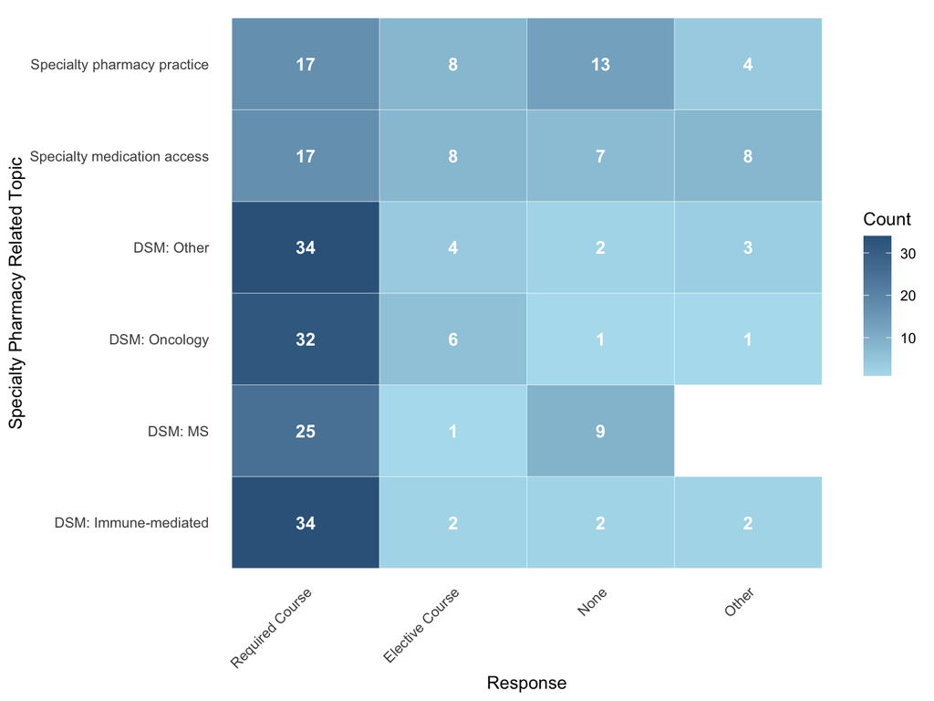

#### 2.3.3.2 Percentage of topics with and without SP faculty

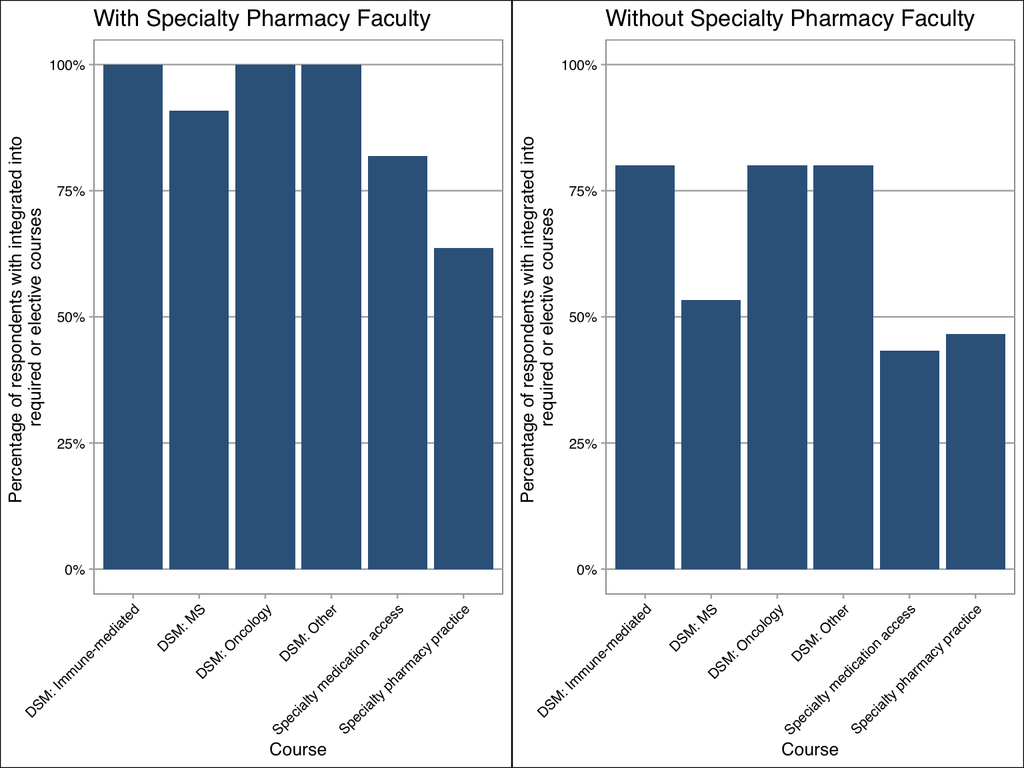

### 2.3.4 List other method(s) that specialty pharmacy content is covered in didactic curriculum:

#### 2.3.4.1 Free text

Specialty medication access process

| x |
| --- |
| none |
| Unsure |
| 2 |
| medication access is covered in labs - in general for meds, but the same concepts apply to specialty meds. |
| None |
| simulation and skills assessment |

### 2.3.5 Please provide the estimated number of contact hours spent on specialty pharmacy content throughout the curriculum:

**Overall**

| **Characteristic** | **N** | **N = 41** |
| --- | --- | --- |
| Specialty pharmacy practice | 23 |  |
| Mean (SD) |  | 4.4 (3.9) |
| Median (IQR) |  | 3.0 (1.0 - 6.0) |
| Range |  | 1.0 - 15.0 |
| Missing |  | 18 |
| Specialty medication access process | 26 |  |
| Mean (SD) |  | 2.5 (2.4) |
| Median (IQR) |  | 2.0 (1.0 - 2.8) |
| Range |  | 0.0 - 12.0 |
| Missing |  | 15 |
| Disease state management: Oncology | 35 |  |
| Mean (SD) |  | 17.0 (15.7) |
| Median (IQR) |  | 12.0 (2.5 - 30.0) |
| Range |  | 0.0 - 60.0 |
| Missing |  | 6 |
| Disease state management: Immune-mediated | 35 |  |
| Mean (SD) |  | 7.8 (6.4) |
| Median (IQR) |  | 6.0 (2.0 - 10.0) |
| Range |  | 0.0 - 20.0 |
| Missing |  | 6 |
| Disease state management: Multiple Sclerosis | 26 |  |
| Mean (SD) |  | 2.1 (1.0) |
| Median (IQR) |  | 2.0 (1.3 - 2.8) |
| Range |  | 0.0 - 4.0 |
| Missing |  | 15 |
| Disease state management: Other specialty conditions | 35 |  |
| Mean (SD) |  | 6.9 (7.0) |
| Median (IQR) |  | 4.0 (1.5 - 10.0) |
| Range |  | 0.0 - 30.0 |
| Missing |  | 6 |

**For respondents with required DSM Oncology**

| **Characteristic** | **N** | **N = 32** |
| --- | --- | --- |
| Specialty pharmacy practice | 17 |  |
| Mean (SD) |  | 4.9 (4.2) |
| Median (IQR) |  | 4.0 (2.0 - 6.0) |
| Range |  | 1.0 - 15.0 |
| Missing |  | 15 |
| Specialty medication access process | 20 |  |
| Mean (SD) |  | 2.9 (2.6) |
| Median (IQR) |  | 2.0 (1.0 - 4.0) |
| Range |  | 1.0 - 12.0 |
| Missing |  | 12 |
| Disease state management: Oncology | 32 |  |
| Mean (SD) |  | 18.3 (15.8) |
| Median (IQR) |  | 14.0 (6.0 - 30.0) |
| Range |  | 0.0 - 60.0 |
| Disease state management: Immune-mediated | 30 |  |
| Mean (SD) |  | 8.7 (6.4) |
| Median (IQR) |  | 8.0 (3.3 - 10.0) |
| Range |  | 0.0 - 20.0 |
| Missing |  | 2 |
| Disease state management: Multiple Sclerosis | 23 |  |
| Mean (SD) |  | 2.1 (1.1) |
| Median (IQR) |  | 2.0 (1.5 - 3.0) |
| Range |  | 0.0 - 4.0 |
| Missing |  | 9 |
| Disease state management: Other specialty conditions | 32 |  |
| Mean (SD) |  | 6.8 (7.1) |
| Median (IQR) |  | 4.0 (1.8 - 10.0) |
| Range |  | 0.0 - 30.0 |

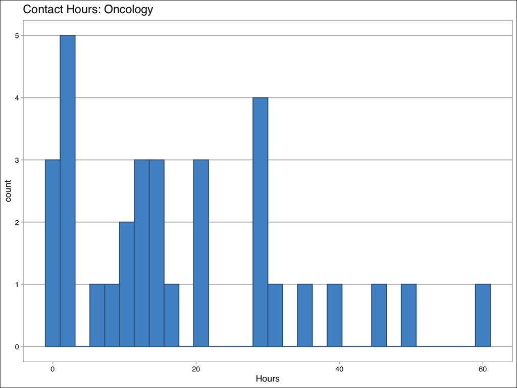

**For respondents with required DSM Immune-mediated**

| **Characteristic** | **N** | **N = 34** |
| --- | --- | --- |
| Specialty pharmacy practice | 20 |  |
| Mean (SD) |  | 4.6 (4.1) |
| Median (IQR) |  | 3.0 (1.0 - 6.3) |
| Range |  | 1.0 - 15.0 |
| Missing |  | 14 |
| Specialty medication access process | 22 |  |
| Mean (SD) |  | 2.6 (2.6) |
| Median (IQR) |  | 2.0 (1.0 - 3.8) |
| Range |  | 0.0 - 12.0 |
| Missing |  | 12 |
| Disease state management: Oncology | 32 |  |
| Mean (SD) |  | 18.3 (15.8) |
| Median (IQR) |  | 14.0 (6.8 - 30.0) |
| Range |  | 0.0 - 60.0 |
| Missing |  | 2 |
| Disease state management: Immune-mediated | 34 |  |
| Mean (SD) |  | 8.0 (6.4) |
| Median (IQR) |  | 7.0 (2.3 - 10.0) |
| Range |  | 0.0 - 20.0 |
| Disease state management: Multiple Sclerosis | 24 |  |
| Mean (SD) |  | 2.1 (1.0) |
| Median (IQR) |  | 2.0 (1.8 - 3.0) |
| Range |  | 0.0 - 4.0 |
| Missing |  | 10 |
| Disease state management: Other specialty conditions | 32 |  |
| Mean (SD) |  | 6.8 (7.1) |
| Median (IQR) |  | 4.0 (1.8 - 10.0) |
| Range |  | 0.0 - 30.0 |
| Missing |  | 2 |

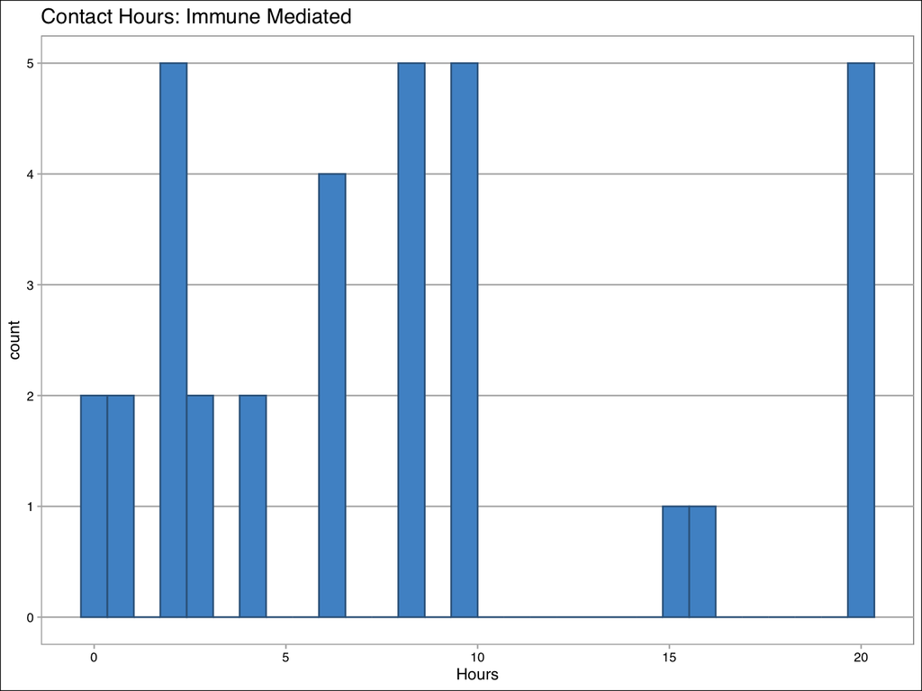

**For respondents with required DSM Multiple Sclerosis**

| **Characteristic** | **N** | **N = 25** |
| --- | --- | --- |
| Specialty pharmacy practice | 15 |  |
| Mean (SD) |  | 4.7 (4.2) |
| Median (IQR) |  | 4.0 (1.5 - 6.0) |
| Range |  | 1.0 - 15.0 |
| Missing |  | 10 |
| Specialty medication access process | 18 |  |
| Mean (SD) |  | 2.8 (2.7) |
| Median (IQR) |  | 2.0 (1.0 - 3.8) |
| Range |  | 0.0 - 12.0 |
| Missing |  | 7 |
| Disease state management: Oncology | 25 |  |
| Mean (SD) |  | 16.5 (14.6) |
| Median (IQR) |  | 12.0 (2.0 - 30.0) |
| Range |  | 0.0 - 50.0 |
| Disease state management: Immune-mediated | 24 |  |
| Mean (SD) |  | 8.0 (6.1) |
| Median (IQR) |  | 6.0 (3.0 - 10.0) |
| Range |  | 0.0 - 20.0 |
| Missing |  | 1 |
| Disease state management: Multiple Sclerosis | 25 |  |
| Mean (SD) |  | 2.1 (1.0) |
| Median (IQR) |  | 2.0 (1.0 - 3.0) |
| Range |  | 0.0 - 4.0 |
| Disease state management: Other specialty conditions | 25 |  |
| Mean (SD) |  | 6.3 (7.3) |
| Median (IQR) |  | 4.0 (1.0 - 10.0) |
| Range |  | 0.0 - 30.0 |

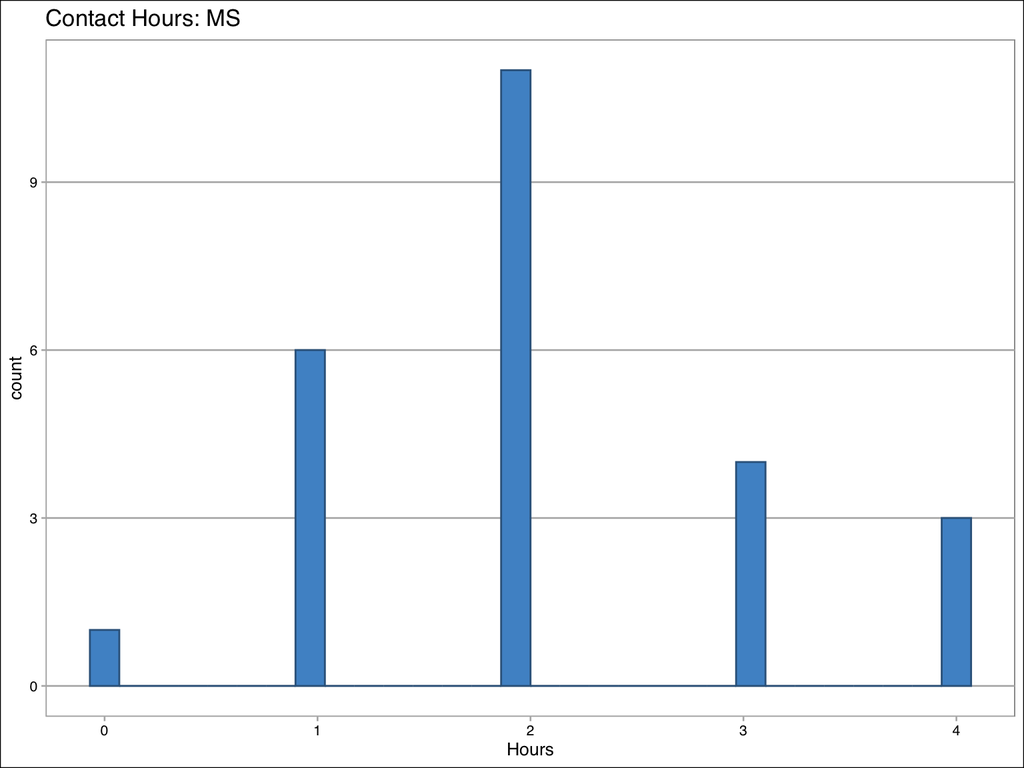

**For respondents with required DSM Other specialty conditions**

| **Characteristic** | **N** | **N = 34** |
| --- | --- | --- |
| Specialty pharmacy practice | 18 |  |
| Mean (SD) |  | 4.7 (4.2) |
| Median (IQR) |  | 3.0 (1.3 - 6.0) |
| Range |  | 1.0 - 15.0 |
| Missing |  | 16 |
| Specialty medication access process | 21 |  |
| Mean (SD) |  | 2.7 (2.6) |
| Median (IQR) |  | 2.0 (1.0 - 4.0) |
| Range |  | 0.0 - 12.0 |
| Missing |  | 13 |
| Disease state management: Oncology | 34 |  |
| Mean (SD) |  | 17.5 (15.7) |
| Median (IQR) |  | 13.0 (4.0 - 30.0) |
| Range |  | 0.0 - 60.0 |
| Disease state management: Immune-mediated | 32 |  |
| Mean (SD) |  | 8.4 (6.4) |
| Median (IQR) |  | 8.0 (3.0 - 10.0) |
| Range |  | 0.0 - 20.0 |
| Missing |  | 2 |
| Disease state management: Multiple Sclerosis | 25 |  |
| Mean (SD) |  | 2.1 (1.0) |
| Median (IQR) |  | 2.0 (1.0 - 3.0) |
| Range |  | 0.0 - 4.0 |
| Missing |  | 9 |
| Disease state management: Other specialty conditions | 34 |  |
| Mean (SD) |  | 6.6 (7.0) |
| Median (IQR) |  | 4.0 (1.3 - 10.0) |
| Range |  | 0.0 - 30.0 |

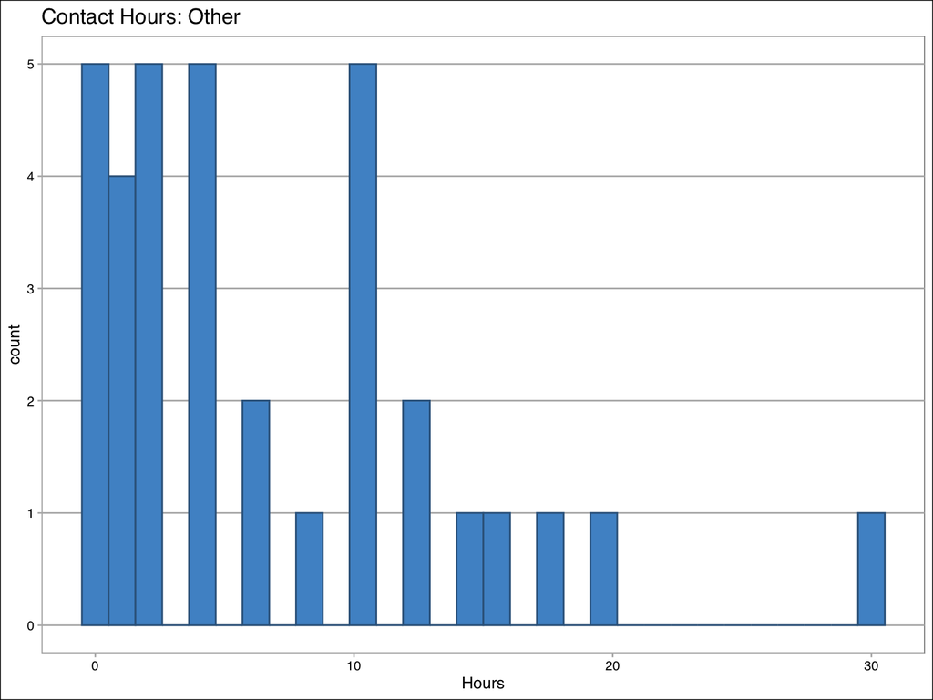

### 2.3.6 Experiential course information

**Granular**

| **Characteristic** | **N** | **N = 41**<sup>1</sup> |
| --- | --- | --- |
| Does your curriculum offer a designated "specialty pharmacy" APPE or an APPE experience based primarily within a specialty pharmacy? | 41 |  |
| No |  | 4 (9.76%) |
| Unsure |  | 8 (19.5%) |
| Yes |  | 29 (70.7%) |
| Please provide the number of available specialty pharmacy sites (locations). | 29 |  |
| Mean (SD) |  | 7.0 (9.1) |
| Median (IQR) |  | 5.0 (2.0 - 8.0) |
| Range |  | 0.0 - 50.0 |
| Missing |  | 12 |
| Please provide the approximate number of experiences available per year. This would be the total number of openings among all specialty pharmacy practice sites. | 29 |  |
| Mean (SD) |  | 21.6 (22.1) |
| Median (IQR) |  | 12.0 (6.0 - 30.0) |
| Range |  | 0.0 - 96.0 |
| Missing |  | 12 |
| Please provide the approximate number of students that take a specialty pharmacy APPE per year (e.g., 8 students per year). | 29 |  |
| Mean (SD) |  | 10.0 (10.7) |
| Median (IQR) |  | 6.0 (4.0 - 12.0) |
| Range |  | 0.0 - 44.0 |
| Missing |  | 12 |

<sup>1</sup> n (%)

**Continuous**

| **Characteristic** | **N** | **N = 41**<sup>1</sup> |
| --- | --- | --- |
| Does your curriculum offer a designated "specialty pharmacy" APPE or an APPE experience based primarily within a specialty pharmacy? | 41 |  |
| No |  | 4 (9.76%) |
| Unsure |  | 8 (19.5%) |
| Yes |  | 29 (70.7%) |
| Please provide the number of available specialty pharmacy sites (locations). | 29 |  |
| Mean (SD) |  | 7.0 (9.1) |
| Median (IQR) |  | 5.0 (2.0 - 8.0) |
| Range |  | 0.0 - 50.0 |
| Missing |  | 12 |
| Please provide the approximate number of experiences available per year. This would be the total number of openings among all specialty pharmacy practice sites. | 29 |  |
| Mean (SD) |  | 21.6 (22.1) |
| Median (IQR) |  | 12.0 (6.0 - 30.0) |
| Range |  | 0.0 - 96.0 |
| Missing |  | 12 |
| Please provide the approximate number of students that take a specialty pharmacy APPE per year (e.g., 8 students per year). | 29 |  |
| Mean (SD) |  | 10.0 (10.7) |
| Median (IQR) |  | 6.0 (4.0 - 12.0) |
| Range |  | 0.0 - 44.0 |
| Missing |  | 12 |

<sup>1</sup> n (%)

**By rural or urban**

| **Characteristic** | **N** | **Primary college/school setting** **Rural**, N = 8<sup>1</sup> | **Primary college/school setting** **Suburban**, N = 15<sup>1</sup> | **Primary college/school setting** **Urban**, N = 18<sup>1</sup> |
| --- | --- | --- | --- | --- |
| Does your curriculum offer a designated "specialty pharmacy" APPE or an APPE experience based primarily within a specialty pharmacy? | 41 |  |  |  |
| No |  | 2 (25.0%) | 0 (0%) | 2 (11.1%) |
| Unsure |  | 2 (25.0%) | 2 (13.3%) | 4 (22.2%) |
| Yes |  | 4 (50.0%) | 13 (86.7%) | 12 (66.7%) |
| Please provide the number of available specialty pharmacy sites (locations). | 29 |  |  |  |
| Mean (SD) |  | 10.0 (2.8) | 3.9 (3.8) | 9.4 (13.2) |
| Median (IQR) |  | 11.0 (9.0 - 12.0) | 2.0 (2.0 - 5.0) | 6.0 (3.0 - 8.5) |
| Range |  | 6.0 - 12.0 | 1.0 - 15.0 | 0.0 - 50.0 |
| Missing |  | 4 | 2 | 6 |
| Please provide the approximate number of experiences available per year. This would be the total number of openings among all specialty pharmacy practice sites. | 29 |  |  |  |
| Mean (SD) |  | 52.8 (36.6) | 14.3 (14.4) | 19.2 (15.2) |
| Median (IQR) |  | 52.5 (32.5 - 72.8) | 10.0 (5.0 - 20.0) | 17.5 (9.0 - 22.3) |
| Range |  | 10.0 - 96.0 | 1.0 - 50.0 | 0.0 - 50.0 |
| Missing |  | 4 | 2 | 6 |
| Please provide the approximate number of students that take a specialty pharmacy APPE per year (e.g., 8 students per year). | 29 |  |  |  |
| Mean (SD) |  | 17.5 (15.6) | 5.9 (5.2) | 11.8 (12.4) |
| Median (IQR) |  | 12.0 (7.5 - 22.0) | 4.0 (3.0 - 7.0) | 6.5 (5.0 - 15.5) |
| Range |  | 6.0 - 40.0 | 1.0 - 20.0 | 0.0 - 44.0 |
| Missing |  | 4 | 2 | 6 |

<sup>1</sup> n (%)

#### 2.3.6.1 In which specialty pharmacies are APPEs offered

**Bar graph**

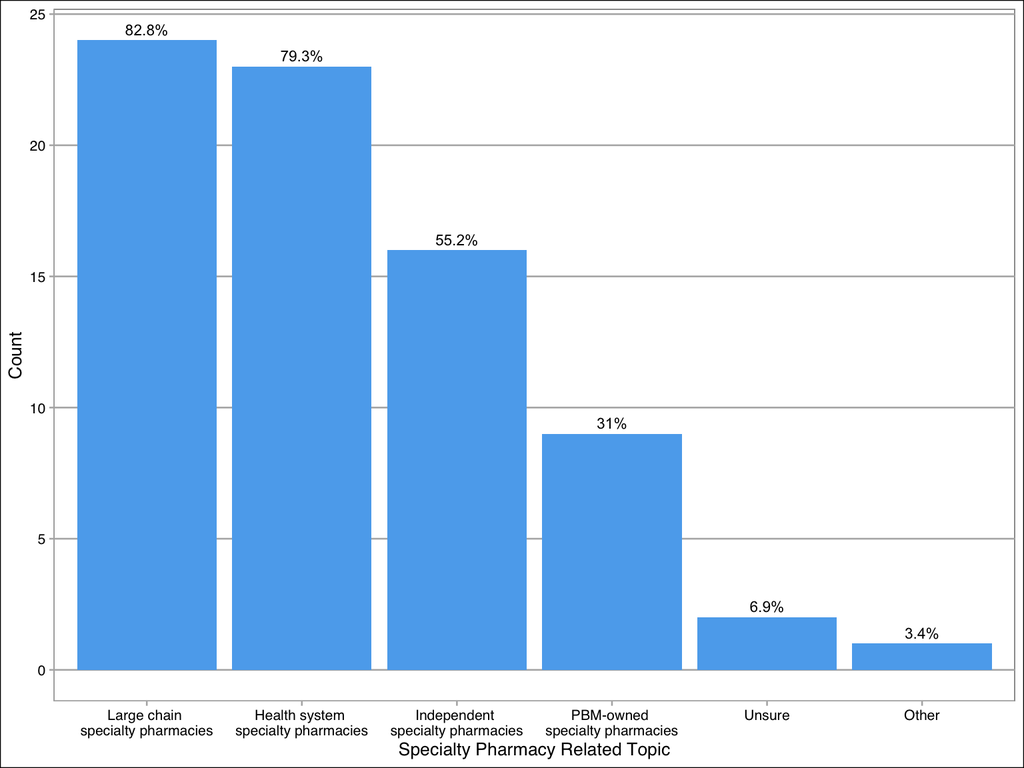

**By participant**

| **Characteristic** | **N = 29**<sup>1</sup> |
| --- | --- |
| Large chain specialty pharmacies (e.g., Walgreens Specialty) | 24 (82.8%) |
| Health system specialty pharmacies | 23 (79.3%) |
| Independent specialty pharmacies | 16 (55.2%) |
| PBM-owned specialty pharmacies (e.g., Express Scripts, CVS Caremark) | 9 (31.0%) |
| Unsure | 2 (6.90%) |
| Other | 1 (3.45%) |

<sup>1</sup> n (%)

**By response**

| **Characteristic** | **N** | **N = 76**<sup>1</sup> |
| --- | --- | --- |
| Selection | 76 |  |
| Large chain specialty pharmacies (e.g., Walgreens Specialty) |  | 24 (31.6%) |
| Health system specialty pharmacies |  | 23 (30.3%) |
| Independent specialty pharmacies |  | 16 (21.1%) |
| PBM-owned specialty pharmacies (e.g., Express Scripts, CVS Caremark) |  | 9 (11.8%) |
| Unsure |  | 2 (2.63%) |
| [Zero selected] |  | 1 (1.32%) |
| Other |  | 1 (1.32%) |

<sup>1</sup> n (%)

### 2.3.7 For EXPERIENTIAL (IPPE/APPE) curriculum, please consider how often the topic listed on the left is covered in a rotation experience

| **Characteristic** | **N** | **N = 41**<sup>1</sup> |
| --- | --- | --- |
| Specialty pharmacy practice (SP business, stakeholders, accreditation, models, role of PharmD) | 41 |  |
| Few or no APPE/IPPE experiences (< 10) |  | 18 (43.9%) |
| Many APPE/IPPE experiences (>20) |  | 2 (4.88%) |
| Some APPE/IPPE experiences (10-20) |  | 10 (24.4%) |
| Unsure |  | 11 (26.8%) |
| Specialty medication access process (benefit investigation, prior authorization, appeal of insurance determination, and financial assistance) | 41 |  |
| Few or no APPE/IPPE experiences (< 10) |  | 15 (36.6%) |
| Many APPE/IPPE experiences (>20) |  | 5 (12.2%) |
| Some APPE/IPPE experiences (10-20) |  | 10 (24.4%) |
| Unsure |  | 11 (26.8%) |
| Disease state management: Oncology | 41 |  |
| Few or no APPE/IPPE experiences (< 10) |  | 11 (26.8%) |
| Many APPE/IPPE experiences (>20) |  | 5 (12.2%) |
| Some APPE/IPPE experiences (10-20) |  | 16 (39.0%) |
| Unsure |  | 9 (22.0%) |
| Disease state management: Immune-mediated (RA, psoriasis, IBD) | 41 |  |
| Few or no APPE/IPPE experiences (< 10) |  | 17 (41.5%) |
| Many APPE/IPPE experiences (>20) |  | 2 (4.88%) |
| Some APPE/IPPE experiences (10-20) |  | 9 (22.0%) |
| Unsure |  | 13 (31.7%) |
| Disease state management: Multiple Sclerosis | 41 |  |
| Few or no APPE/IPPE experiences (< 10) |  | 21 (51.2%) |
| Some APPE/IPPE experiences (10-20) |  | 6 (14.6%) |
| Unsure |  | 14 (34.1%) |
| Disease state management: Other specialty conditions (e.g., HIV, HCV, transplant, movement disorders) | 41 |  |
| Few or no APPE/IPPE experiences (< 10) |  | 15 (36.6%) |
| Many APPE/IPPE experiences (>20) |  | 3 (7.32%) |
| Some APPE/IPPE experiences (10-20) |  | 12 (29.3%) |
| Unsure |  | 11 (26.8%) |

<sup>1</sup> n (%)

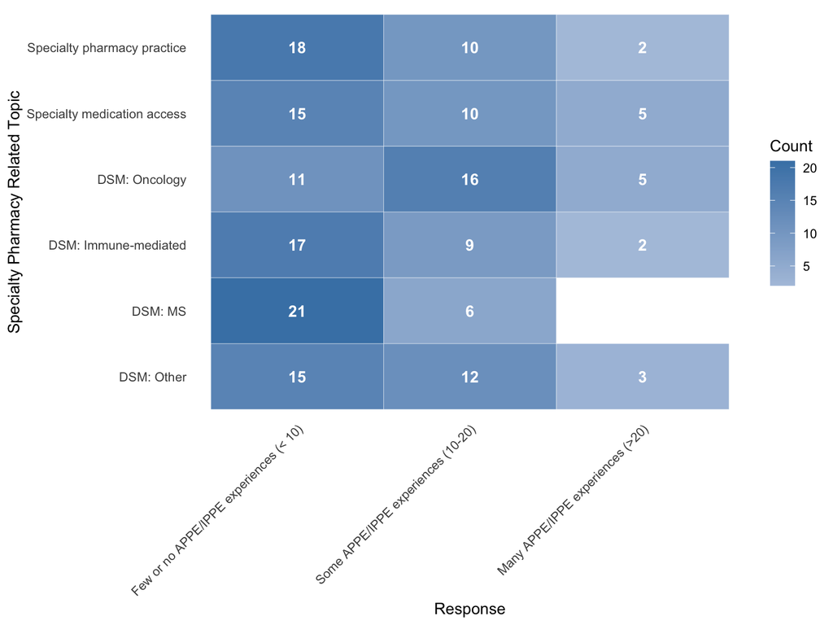

### 2.3.8 Future Perceptions

**Continuous**

| **Characteristic** | **N** | **N = 41**<sup>1</sup> |
| --- | --- | --- |
| How valuable do you perceive specialty pharmacy content to be in your curriculum? | 41 |  |
| Mean (SD) |  | 5.8 (1.8) |
| Median (IQR) |  | 5.0 (5.0 - 7.0) |
| Range |  | 1.0 - 9.0 |
| How do you anticipate specialty pharmacy content changing in your curriculum in the next 5-10 years? | 41 |  |
| Moderate increase |  | 23 (56.1%) |
| Moderate reduction |  | 1 (2.44%) |
| No change |  | 13 (31.7%) |
| Significant increase |  | 4 (9.76%) |
| Please provide any additional comments you may have related to specialty pharmacy in school/college of pharmacy curricula. | 8 |  |
| APPE availability fluctuates significantly so difficult to estimate |  | 1 (12.5%) |
| I don't think it is the disease state information we need to improve upon but on the delivery of care at the pharmacy. This will continue to be a growing niche and our graduates should be competent to… |  | 1 (12.5%) |
| I think that specialty pharmacy is a growing practice and will become more competitive for pharmacists to enter this area of practice. We see a growing interest of our students. We need to figure out … |  | 1 (12.5%) |
| None |  | 1 (12.5%) |
| Our school, like others, incorporates applicable specialty products throughout each of the therapeutics courses where these are marketed. These are rarely first-line therapies but are discussed regard… |  | 1 (12.5%) |
| We have 4 PGY-1 residencies that have a focus in specialty pharmacy |  | 1 (12.5%) |
| We use the ACCP toolkit to guide the clinical content related to specialty pharmacy. We also have an Oncology Practice Management elective that goes over specialty pharmacy, etc. |  | 1 (12.5%) |
| We used to have a specialty course, but it was a challenge to get students interested in the materials (as it was focused on more of the SP process compared to specialty diseases). |  | 1 (12.5%) |
| Missing |  | 33 |

<sup>1</sup> n (%)

**Granular**

| **Characteristic** | **N** | **N = 41**<sup>1</sup> |
| --- | --- | --- |
| How valuable do you perceive specialty pharmacy content to be in your curriculum? | 41 |  |
| 1 |  | 1 (2.44%) |
| 2 |  | 1 (2.44%) |
| 3 |  | 1 (2.44%) |
| 4 |  | 1 (2.44%) |
| 5 |  | 20 (48.8%) |
| 6 |  | 2 (4.88%) |
| 7 |  | 8 (19.5%) |
| 8 |  | 4 (9.76%) |
| 9 |  | 3 (7.32%) |
| How do you anticipate specialty pharmacy content changing in your curriculum in the next 5-10 years? | 41 |  |
| Moderate increase |  | 23 (56.1%) |
| Moderate reduction |  | 1 (2.44%) |
| No change |  | 13 (31.7%) |
| Significant increase |  | 4 (9.76%) |
| Please provide any additional comments you may have related to specialty pharmacy in school/college of pharmacy curricula. | 8 |  |
| APPE availability fluctuates significantly so difficult to estimate |  | 1 (12.5%) |
| I don't think it is the disease state information we need to improve upon but on the delivery of care at the pharmacy. This will continue to be a growing niche and our graduates should be competent to… |  | 1 (12.5%) |
| I think that specialty pharmacy is a growing practice and will become more competitive for pharmacists to enter this area of practice. We see a growing interest of our students. We need to figure out … |  | 1 (12.5%) |
| None |  | 1 (12.5%) |
| Our school, like others, incorporates applicable specialty products throughout each of the therapeutics courses where these are marketed. These are rarely first-line therapies but are discussed regard… |  | 1 (12.5%) |
| We have 4 PGY-1 residencies that have a focus in specialty pharmacy |  | 1 (12.5%) |
| We use the ACCP toolkit to guide the clinical content related to specialty pharmacy. We also have an Oncology Practice Management elective that goes over specialty pharmacy, etc. |  | 1 (12.5%) |
| We used to have a specialty course, but it was a challenge to get students interested in the materials (as it was focused on more of the SP process compared to specialty diseases). |  | 1 (12.5%) |
| Missing |  | 33 |

<sup>1</sup> n (%)